# Hypothesis Testing II

Zhaoxia Yu

## Load packages, read data

```r
library(tidyverse)
library(ggplot2)
alzheimer_data <- read.csv('data/alzheimer_data.csv') %>%
  select(id, diagnosis, age, educ, female, height, weight, lhippo, rhippo) %>%
  mutate(diagnosis = as.factor(diagnosis),
         female = as.factor(female),
         hippo=lhippo + rhippo)


alzheimer_healthy <- read.csv('data/alzheimer_data.csv') %>%
  select(id, diagnosis, age, educ, female, height, weight, lhippo, rhippo) %>%
  mutate(diagnosis = as.factor(diagnosis),
         female = as.factor(female),
         hippo=lhippo+rhippo) %>%
  filter(diagnosis==0)
```

## A LIST OF QUESTIONS

- Ex 1. Is the hippocampal volume of healthy males greater than 6 cm$^3$? (Done)
- Ex 2. Is the proportion of healthy adults with a right hippocampal volume > 3cm$^3$ equal to 50%? (can be done by using the method for testing a proportion: z-test)
- Ex 3. Do healthy men and women have the same mean left hippocampal volume?
- Ex 4. Is the left hippocampal volume equal to the right hippocampal volume in humans?
- Ex 5. Is having a large hippocampus (> 7 cm$^3$) associated with gender?
- Ex 6. Is hippocampal volume correlated with age in healthy adults?
- Ex 7. Does left hippocampal volume differ across diagnostic groups?

## EXAMPLE 3: Two-Sample t-test

Ex 3. Do healthy men and women have the same mean left hippocampal volume?

- Categorical (gender) and Numerical (Left Hippocampus) :
  - Side by Side Boxplot
  - Side by Side Violin
  - 2 Histograms

## Example 3: Visualization – boxplot

```r
ggplot(data= alzheimer_healthy,
       mapping= aes(x= female,
                    y=lhippo,
                    fill=female)) +
  geom_boxplot()+
  labs(
    title="Boxplot of lhippo by Gender",
    x="Gender",
    y="LHippo volume (cm^3)") +
  theme_minimal()
```

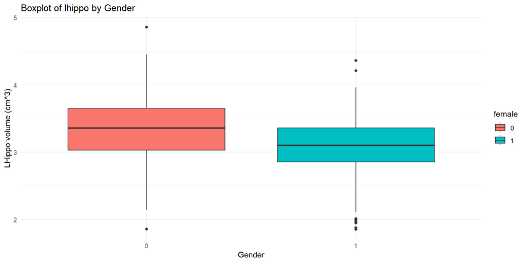

## Example 3: Visualization – violin

```r
ggplot(data= alzheimer_healthy,
       mapping= aes(x= female,
                    y=lhippo,
                    fill=female)) +
  geom_violin()+
  labs(
    title="Violin of lhippo by Gender",
    x="Gender",
    y="LHippo volume (cm^3)") +
  theme_minimal()
```

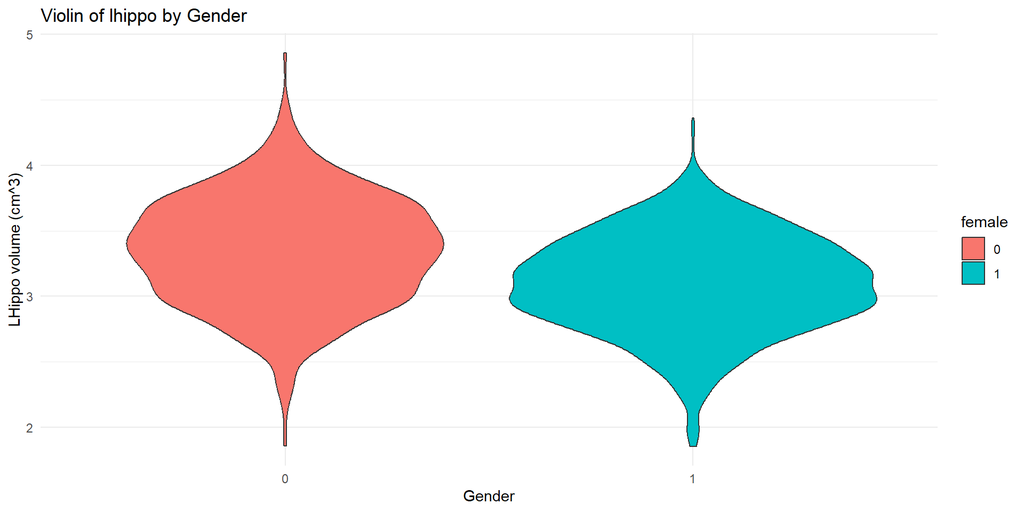

## Example 3: Visualization – histogram

```r
ggplot(data= alzheimer_healthy,
       mapping= aes(x=lhippo,
                    fill=female)) +
  geom_histogram(bins=35)+
  labs(
    title="Histogram of Lhippo by Gender",
    x="LHippo volume (cm^3)",
    y="Count")
```

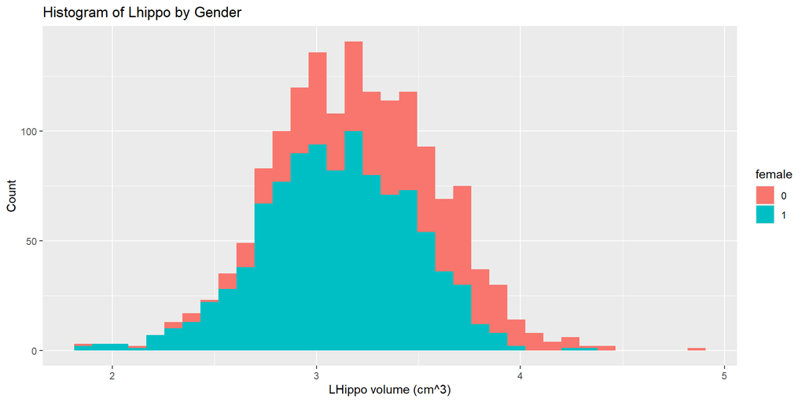